# Lesson Plans

Alea Wilbur

5/5/2021

# Survey Data Prep

# Readings and Resources

Introductory Statistics with R - Peter Dalgaard (2002)

Tidyverse Skills for Data Science in R (2021)

# Finding Data

[UIC’s data sources](https://researchguides.uic.edu/c.php?g=252510&p=5246067) UIC has a list of data sources of various types categorized as “Research Tools” and “Policy Documents” If you don’t remember what your options are, this is a good place to start. Links to HUD, American Community Survey, USA Gov, CMAP, National Low Income Housing Coalition, Chicago Data Portal, just to name a few. UIC also allow students to access other large data repositories such as ICPSR, Policy Map, and more.

[UIC data management tips] (https://researchguides.uic.edu/dataplans/datarepositories#s-lg-box-18625329)

# Framing

Framing is the way that a statistic is reported. Context or comparison groups can influence the interpretation of the statistic. Calculating proportions instead of actual numbers sometimes helps provide the true frame.

[COVID Cases](https://covid19datahub.io/) Guidotti, E., Ardia, D., (2020), “COVID-19 Data Hub”, Journal of Open Source Software 5(51):2376, doi: 10.21105/joss.02376.

```r
#install.packages("COVID19")
library("COVID19")
x <- covid19("USA", level = 2)
```

[output not shown]

```r
x
```

```
## # A tibble: 28,342 x 38
## # Groups:   id [56]
##    id     date       vaccines tests confirmed recovered deaths  hosp  vent   icu
##    <chr>  <date>        <dbl> <dbl>     <dbl>     <int>  <int> <dbl> <int> <int>
##  1 121cd~ 2020-01-01       NA    NA        NA        NA     NA    NA    NA    NA
##  2 121cd~ 2020-01-02       NA    NA        NA        NA     NA    NA    NA    NA
##  3 121cd~ 2020-01-03       NA    NA        NA        NA     NA    NA    NA    NA
##  4 121cd~ 2020-01-04       NA    NA        NA        NA     NA    NA    NA    NA
##  5 121cd~ 2020-01-05       NA    NA        NA        NA     NA    NA    NA    NA
##  6 121cd~ 2020-01-06       NA    NA        NA        NA     NA    NA    NA    NA
##  7 121cd~ 2020-01-07       NA    NA        NA        NA     NA    NA    NA    NA
##  8 121cd~ 2020-01-08       NA    NA        NA        NA     NA    NA    NA    NA
##  9 121cd~ 2020-01-09       NA    NA        NA        NA     NA    NA    NA    NA
## 10 121cd~ 2020-01-10       NA    NA        NA        NA     NA    NA    NA    NA
## # ... with 28,332 more rows, and 28 more variables: population <dbl>,
## #   school_closing <int>, workplace_closing <int>, cancel_events <int>,
## #   gatherings_restrictions <int>, transport_closing <int>,
## #   stay_home_restrictions <int>, internal_movement_restrictions <int>,
## #   international_movement_restrictions <int>, information_campaigns <int>,
## #   testing_policy <int>, contact_tracing <int>, stringency_index <dbl>,
## #   iso_alpha_3 <chr>, iso_alpha_2 <chr>, iso_numeric <int>, currency <chr>,
## #   administrative_area_level <int>, administrative_area_level_1 <chr>,
## #   administrative_area_level_2 <chr>, administrative_area_level_3 <lgl>,
## #   latitude <dbl>, longitude <dbl>, key <chr>, key_google_mobility <chr>,
## #   key_apple_mobility <chr>, key_numeric <int>, key_alpha_2 <chr>
```

A city reports that one specific street recycles 2.2 times as much as any other street.  
- Are the streets the same length?  
- Do equal numbers of people live on the streets?

Measuring recycling at the street level isn’t a useful statistic unless streets are otherwise identical.

Alternatives:  
- Recycling amount per living unit  
- recycling amount per person  
- Compare it to the amount of trash  
We want to to adjust the amount recycled to take into account the number of people on the street.

Water Usage!  
Some districts compare themselves to other districts or cities compare themselves to other cities. Measuring the water used per capita per day.

Alternatives:  
- water use per acre  
- Calculate proportions instead of raw numbers

Findings show that water usage is highest for wealthy neighborhoods with large properties.

Expenditures

```r
# TaxExpenditure <- data.frame(Expenditure.Type = c(factor("Industry & workforce", "Defence",
#                                                        "Social security & welfare",
#                                                        "Community services & culture",
#                                                        "Health",
#                                                        "Infrastructure, transport & energy",
#                                                        "Education",
#                                                        "General government services")),
#                              Expenditure.Amount = c(14.843, 21.277, 121.907, 8.044, 59.858, 13.221, 29.870, 96.797))
#
# ggplot(data = TaxExpenditure,
#        aes(x = reorder(Expenditure.Type, Expenditure.Amount), y = Expenditure.Amount, fill = Expenditure.Type)) +
#   geom_bar(stat = "identity") +
#   scale_y_continuous(breaks = seq(0, 125, by = 25), limits = c(0,125), expand=c(0,0)) +
#   scale_x_discrete(labels=function(x) str_wrap(x, width=20)) +
#   labs(x="Expenditure type", y="Expenditure ($millions)") +
#   scale_fill_brewer(palette = "Set3") +
#   coord_flip() +
#   theme(panel.grid.minor.y=element_blank(),
#         panel.grid.major.x = element_line(color = "gray"),
#         panel.background = element_blank(),
#         axis.line = element_line(color="gray", size = 1),
#         axis.text=element_text(size=10),
#         axis.title=element_text(size=15),
#         plot.margin=margin(5,15,5,5),
#         legend.position = "none")
```

### Vocab

Bimodal distriubtion: a set of observations where two values occur more than often than the other values. A graph of the frequency shows two peaks in the distribution.

**Accuracy**: How close a number is to the true quantity being measured. Different than precision. **Precision**: A measure of the level of detail, or resolution, in a number. 98.683 is more precise than 100, but if the true value is 101.00, than a measurement equal to 100 is more accurate.

**Incidence**: Number of new cases reported in a specific time **Prevalence**: Number of existing caes (cumulative)

# Univariate Data

Univariate data involves analyzing one variable. It does not deal with causal relationships and it is mostly used to describe the variable.

## Categorical Data

A categorical variable can only take on a specific set of values representing a set of possible categories. Even if a number is assigned to it for data recording purposes, the numbers do not mean anything (eg. taking the average of: 1. Blue, 2. Orange, 3. Green). This occurs most often when analyzing survey data when information is stored as numbered responses (that work for analysis) and labels (that describe the survey options).

Categorical variables are also called *nominal* variables

```r
# good vs bad examples. Link images.

#quicktab(anes$V201429)
#table(anes$V201429)

#V202118 # How does the respondent normally vote?
```

Frequencies, proportions, bar charts

## Numerical Data

```r
# good vs bad examples. Link images.
```

### Continuous Variables

Data that can take on any value in an interval Ex. Age of respondents

```r
# ANES 2020 Respondent Age
source("anes_functions.R", local = knitr::knit_global())
source("anes_recodes.R", local = knitr::knit_global())


attributes(anes$V201507x)
```

```
## $label
## [1] "PRE: SUMMARY: Respondent age"
##
## $format.stata
## [1] "%12.0g"
##
## $class
## [1] "haven_labelled" "vctrs_vctr"     "double"
##
## $labels
##         -9. Refused 80. Age 80 or older
##                  -9                  80
```

```r
#anes %>% quicktab(V201507x, "Age")

#quicktab(anes$agecat, "Age")
table(anes$agecat)
```

```
## < table of extent 0 >
```

### Discrete

Data can be only integer values, such as counts.

```r
# frequency table, number of people that responded. Can't be fraction.
```

### Ordinal

This is a type of categorical variable where the responses have a meaningful order. Age groups, income brackets, Likert scales (Strongly Dislike, Dislike, Neutral, Like, Strongly Like) are all ordinal variables.

These you must approach carefully when doing analysis.

```r
# Income bracket with unequal bracket ranges. Don't just calculate the Average income bracket number.
```

## Data Distribution

The density for a continuous distribution is a measure of relative probabily for getting a value close to x. The probability of getting a value in a particular interval is the area under the corresponding part of the curve. (Calc flashbacks…)

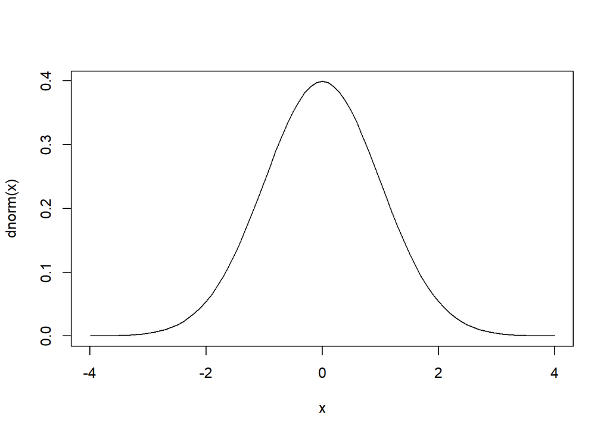

```r
x <- seq(-4, 4, 0.1)
plot(x, dnorm(x), type = "l") # type = "l" tells R to connect the dots with a line instead of just graphing the points
```

- Frequency Tables
- Histograms hist(x)
- Quantiles
- Q-Q plots
- Box Plots

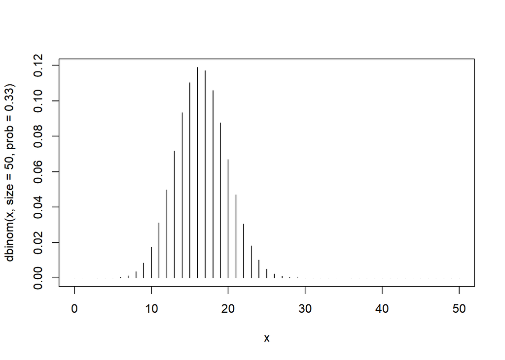

```r
x <- 0:50
plot(x, dbinom(x, size = 50, prob = .33), type = "h") # h for histogram
```

But how do we describe the data or graphs?

### Central Tendency

(Central Tendency RMD)

**Mean**: The average. Has a formula.  
In Excel: =AVERAGE((CELL_1 + CELL_2 + CELL_3)/(Number_Of_Cells))

```r
( 4 + 6 + 2 ) / 3
```

```
## [1] 4
```

Calculate the mean

```r
# link generic forumla for equation or type it in
#mean()
```

Discussion on outliers, potential use of trim mean

```r
#graph outliers
# trimmed mean
```

**Median**: Think of the thing between lanes in a road - the median. It is in the center. Equally distanced between both sides. Half of the observations are on one side, and half are on the other. Medians are useful for “measuring the middle” when there are outliers.

**Mode**: Observation that occurs the most often. When is the mean an inappropriate statistic? Bimodal distributions, groups. The mean and median might be somewhere between the two but does that tell us anything useful? Bimodal distributions indicate heterogeneity in the sample. If possible, look at the statistics for each group to gain more context.

Use the Central Tendency Lesson.RMD file

Discuss left and right skewed data

```r
# Murder rates in cities raw vs weighted by population
```

### Measures of Dispersion

How tightly clustered or spread out is your data?

Variance,Deviations, Range, Percentile, Degrees of Freedom

**Variation**: The tendency of variables to change from measurement to measurement  
- Each measurement includes a small amount of error  
- Visualize the distribution of a variables values to find patterns in variation  
- Chicago traffic speed example

**Variability**: The sum of squared deviations from the mean divided by n-1, where n is the number of data values.

**Standard deviation**: Square root of the variance.

```r
# include images I made from 402 discussin standard deviation and variability
```

var() sd() min() max() range() summary()

## Percentage Change

ERCOT data on the Texas Winter Storm Examples in slides on taxes changing, comparison of baselines

# Bivariate Data

Bivariate data is used to find out if there is a relationship between two different variables. It is frequently represented with scatter plots where one variable is on the X axis and the other is on the Y axis. If the data seems to fit a line or curve then there may be a relationship, or correlation, between the two variables. Always be careful when examining relationships. Many variables may appear related when in fact their relationship happened by chance or a third variable is influencing both variables.

*Test of Association*: Used to test whether two variables are related to one another or not  
- Depends on the nature of the variables you are studying (nominal, ordinal, interval) and number of categories  
- Depends on the nature of the question you’re answering (independence, agreement of coders, effect of an intervention, etc.)

### Patterns and Models

- Could this pattenr happen by chance?
- How do you describe the relationship implied by the pattern?
- How strong is the relationship implied by the pattern?
- What other variables might affect the relationship?
- Does the relationship change if you look at individual subgroups of the data?

“Variation creates uncertainty but covariation reduces it.” - pg 106

## Correlation

Correlation is the extent that two continuous (interval or ratio level) variables are related. A relationship exists when knowing the value of one variavble is useful for predicting the value of a second variable.

```r
set.seed(1827)
a.random = rnorm(50)

b.data = data.frame(replicate(100, rnorm(50)))

cor.size = vector()
for (i in 1: 100)
  cor.size[i] = cor.test(a.random, b.data[,i])$estimate

cor.results = vector()
for (i in 1: 100)
   cor.results[i] = cor.test(a.random, b.data[,i])$p.value
```

**Correlation Coefficient**: symmetric, scale-invariant measure of association between two variables  
- Ranges from -1 to +1.  
- Strength of Correlation: 0 means no correlation, -1 and +1 imply perfect correlation (either one increases as the other decreases [-1] or they move in the same direction[+1])

“A large and common mistake is to compute correlations of data that are not approximated by bi-variate normal data. Averages, standard deviations and correlations are popular summary statistics for two-dimensional data because, for the bivariate normal distribution, these five parameters fully describe the distribution. However, there are many examples of data that are not well approximated by bivariate normal data. Gene expression data, for example, tends to have a distribution with a very fat right tail.”

```r
# income summary, ordinal
# head(ANES2020$V202468x )
```

### Pearson Correlation

- assumes there is a normal distribution
- cor() can be used to compute correlation between two or more vectors
- cor.test() tells you if the correlation is significantly different than zero
  - cor.test() has options for different correlation calculations (pearson (default), spearman, kendall)
  - Spearman and Kendall correlation methods are NON-parametric tests, meaning the variables do not meet the assumptions based on a normal distribution. For this course, you do not need to worry about non-parametric tests BUT if you were doing your own analysis, you must remember that the type of test you use depends on your data and look into which tests are appropriate.

```r
#cor(variable1, variable 2, use = "complete.obs")
# cor.test(v1, v2)
# cor.test(v1, v2, method = "spearman") # Spearman's p and Kendall for nonparametric
```

### Scatterplots

```r
# ggplot() + geom_point()
# ggscatter
```

## Two-Way Tables

- Contingency tables: A tally of counts between two or more categorical variables.

```r
# limits to campaign spending and
#ANES%>% table(V202225, V)
```

- Violin plots: Frequently used for changes in population age
- Boxplots: For categorical and numeric data
- Facet Wrap

### Interpreting

### Creating

### Change Over Time

# Cleaning Data

*Reread Week 3: Tibble lecture for reminders on what to add*

```r
DisasterDeclarations <- read_xlsx("C:/Users/aleaw/OneDrive/Desktop/PhD Spring 2021/Project Data/DisasterDeclarationsSummaries.xlsx")


DisasterSummary<- DisasterDeclarations %>%
  select(femaDeclarationString:declarationTitle, fipsStateCode:declarationRequestNumber) %>%
  filter(designatedArea == c("Broward (County)", "Miami-Dade (County)"),
        fipsCountyCode > 0) %>%
  group_by(fipsStateCode, fipsCountyCode, designatedArea, fyDeclared, incidentType) %>%
  summarize(declarations = n())
#write_csv(DisasterSummary, "C:/Users/aleaw/OneDrive/Desktop/LessonPlans/PPOL105_Excel_Files/BrowardDisasters.csv")
DisasterSummary %>% kable()
```

| fipsStateCode | fipsCountyCode | designatedArea | fyDeclared | incidentType | declarations |
| --- | --- | --- | --- | --- | --- |
| 12 | 11 | Broward (County) | 1965 | Hurricane | 1 |
| 12 | 11 | Broward (County) | 1977 | Freezing | 1 |
| 12 | 11 | Broward (County) | 1985 | Freezing | 1 |
| 12 | 11 | Broward (County) | 1990 | Freezing | 1 |
| 12 | 11 | Broward (County) | 1992 | Hurricane | 1 |
| 12 | 11 | Broward (County) | 1998 | Fire | 1 |
| 12 | 11 | Broward (County) | 1998 | Hurricane | 1 |
| 12 | 11 | Broward (County) | 2000 | Hurricane | 2 |
| 12 | 11 | Broward (County) | 2001 | Freezing | 1 |
| 12 | 11 | Broward (County) | 2001 | Severe Storm(s) | 1 |
| 12 | 11 | Broward (County) | 2004 | Hurricane | 2 |
| 12 | 11 | Broward (County) | 2005 | Hurricane | 2 |
| 12 | 11 | Broward (County) | 2008 | Severe Storm(s) | 1 |
| 12 | 11 | Broward (County) | 2017 | Hurricane | 2 |
| 12 | 11 | Broward (County) | 2020 | Biological | 2 |
| 12 | 11 | Broward (County) | 2020 | Hurricane | 1 |
| 12 | 86 | Miami-Dade (County) | 2003 | Severe Storm(s) | 1 |
| 12 | 86 | Miami-Dade (County) | 2004 | Hurricane | 1 |
| 12 | 86 | Miami-Dade (County) | 2005 | Hurricane | 2 |
| 12 | 86 | Miami-Dade (County) | 2008 | Severe Storm(s) | 1 |

```r
Claims <- read_csv("C:/Users/aleaw/OneDrive/Desktop/PhD Spring 2021/Project Data/SampleFiles/FEMAClaims.csv")
claimssummary <- Claims %>%
  select(countyCode, state, yearOfLoss)%>%
  filter(countyCode == c("12011" , "12086"),
         yearOfLoss > 1999) %>%
  group_by(countyCode, state, yearOfLoss) %>%
  summarize(claims = n())
write_csv(claimssummary, "C:/Users/aleaw/OneDrive/Desktop/LessonPlans/PPOL105_Excel_Files/BrowardInsuranceClaims.csv")
claimssummary %>% kable()
```

| countyCode | state | yearOfLoss | claims |
| --- | --- | --- | --- |
| 12011 | FL | 2000 | 173 |
| 12011 | FL | 2001 | 42 |
| 12011 | FL | 2002 | 40 |
| 12011 | FL | 2003 | 93 |
| 12011 | FL | 2004 | 154 |
| 12011 | FL | 2005 | 800 |
| 12011 | FL | 2006 | 31 |
| 12011 | FL | 2007 | 47 |
| 12011 | FL | 2008 | 53 |
| 12011 | FL | 2009 | 188 |
| 12011 | FL | 2010 | 38 |
| 12011 | FL | 2011 | 163 |
| 12011 | FL | 2012 | 156 |
| 12011 | FL | 2013 | 47 |
| 12011 | FL | 2014 | 39 |
| 12011 | FL | 2015 | 32 |
| 12011 | FL | 2016 | 21 |
| 12011 | FL | 2017 | 442 |
| 12011 | FL | 2018 | 21 |
| 12011 | FL | 2019 | 124 |
| 12011 | FL | 2020 | 22 |
| 12086 | FL | 2000 | 1258 |
| 12086 | FL | 2001 | 23 |
| 12086 | FL | 2002 | 44 |
| 12086 | FL | 2003 | 35 |
| 12086 | FL | 2004 | 92 |
| 12086 | FL | 2005 | 1703 |
| 12086 | FL | 2006 | 28 |
| 12086 | FL | 2007 | 53 |
| 12086 | FL | 2008 | 45 |
| 12086 | FL | 2009 | 172 |
| 12086 | FL | 2010 | 35 |
| 12086 | FL | 2011 | 73 |
| 12086 | FL | 2012 | 77 |
| 12086 | FL | 2013 | 85 |
| 12086 | FL | 2014 | 28 |
| 12086 | FL | 2015 | 53 |
| 12086 | FL | 2016 | 20 |
| 12086 | FL | 2017 | 1006 |
| 12086 | FL | 2018 | 22 |
| 12086 | FL | 2019 | 75 |
| 12086 | FL | 2020 | 269 |

### Pivot

```r
disasterswide <-pivot_wider(DisasterSummary,
                             names_from = c(fyDeclared),
                             names_sep = "_",
                             values_from = c(declarations)
                             )
disasterswide %>% kable()
```

| fipsStateCode | fipsCountyCode | designatedArea | incidentType | 1965 | 1977 | 1985 | 1990 | 1992 | 1998 | 2000 | 2001 | 2004 | 2005 | 2008 | 2017 | 2020 | 2003 |
| --- | --- | --- | --- | --- | --- | --- | --- | --- | --- | --- | --- | --- | --- | --- | --- | --- | --- |
| 12 | 11 | Broward (County) | Hurricane | 1 | NA | NA | NA | 1 | 1 | 2 | NA | 2 | 2 | NA | 2 | 1 | NA |
| 12 | 11 | Broward (County) | Freezing | NA | 1 | 1 | 1 | NA | NA | NA | 1 | NA | NA | NA | NA | NA | NA |
| 12 | 11 | Broward (County) | Fire | NA | NA | NA | NA | NA | 1 | NA | NA | NA | NA | NA | NA | NA | NA |
| 12 | 11 | Broward (County) | Severe Storm(s) | NA | NA | NA | NA | NA | NA | NA | 1 | NA | NA | 1 | NA | NA | NA |
| 12 | 11 | Broward (County) | Biological | NA | NA | NA | NA | NA | NA | NA | NA | NA | NA | NA | NA | 2 | NA |
| 12 | 86 | Miami-Dade (County) | Severe Storm(s) | NA | NA | NA | NA | NA | NA | NA | NA | NA | NA | 1 | NA | NA | 1 |
| 12 | 86 | Miami-Dade (County) | Hurricane | NA | NA | NA | NA | NA | NA | NA | NA | 1 | 2 | NA | NA | NA | NA |

```r
disasterswide2 <- pivot_wider(DisasterSummary,
                             names_from = c(incidentType),
                             names_glue = "{incidentType}_{.value}",
                             values_from = c(declarations)
                             )
disasterswide2 %>% kable()
```

| fipsStateCode | fipsCountyCode | designatedArea | fyDeclared | Hurricane_declarations | Freezing_declarations | Fire_declarations | Severe Storm(s)_declarations | Biological_declarations |
| --- | --- | --- | --- | --- | --- | --- | --- | --- |
| 12 | 11 | Broward (County) | 1965 | 1 | NA | NA | NA | NA |
| 12 | 11 | Broward (County) | 1977 | NA | 1 | NA | NA | NA |
| 12 | 11 | Broward (County) | 1985 | NA | 1 | NA | NA | NA |
| 12 | 11 | Broward (County) | 1990 | NA | 1 | NA | NA | NA |
| 12 | 11 | Broward (County) | 1992 | 1 | NA | NA | NA | NA |
| 12 | 11 | Broward (County) | 1998 | 1 | NA | 1 | NA | NA |
| 12 | 11 | Broward (County) | 2000 | 2 | NA | NA | NA | NA |
| 12 | 11 | Broward (County) | 2001 | NA | 1 | NA | 1 | NA |
| 12 | 11 | Broward (County) | 2004 | 2 | NA | NA | NA | NA |
| 12 | 11 | Broward (County) | 2005 | 2 | NA | NA | NA | NA |
| 12 | 11 | Broward (County) | 2008 | NA | NA | NA | 1 | NA |
| 12 | 11 | Broward (County) | 2017 | 2 | NA | NA | NA | NA |
| 12 | 11 | Broward (County) | 2020 | 1 | NA | NA | NA | 2 |
| 12 | 86 | Miami-Dade (County) | 2003 | NA | NA | NA | 1 | NA |
| 12 | 86 | Miami-Dade (County) | 2004 | 1 | NA | NA | NA | NA |
| 12 | 86 | Miami-Dade (County) | 2005 | 2 | NA | NA | NA | NA |
| 12 | 86 | Miami-Dade (County) | 2008 | NA | NA | NA | 1 | NA |

```r
disasterswide3 <- pivot_wider(DisasterSummary,
                             names_from = c(fyDeclared, incidentType),
                             values_from = c(declarations))
disasterswide3 %>% kable()
```

| fipsStateCode | fipsCountyCode | designatedArea | 1965_Hurricane | 1977_Freezing | 1985_Freezing | 1990_Freezing | 1992_Hurricane | 1998_Fire | 1998_Hurricane | 2000_Hurricane | 2001_Freezing | 2001_Severe Storm(s) | 2004_Hurricane | 2005_Hurricane | 2008_Severe Storm(s) | 2017_Hurricane | 2020_Biological | 2020_Hurricane | 2003_Severe Storm(s) |
| --- | --- | --- | --- | --- | --- | --- | --- | --- | --- | --- | --- | --- | --- | --- | --- | --- | --- | --- | --- |
| 12 | 11 | Broward (County) | 1 | 1 | 1 | 1 | 1 | 1 | 1 | 2 | 1 | 1 | 2 | 2 | 1 | 2 | 2 | 1 | NA |
| 12 | 86 | Miami-Dade (County) | NA | NA | NA | NA | NA | NA | NA | NA | NA | NA | 1 | 2 | 1 | NA | NA | NA | 1 |

```r
disasterswide4 <-   DisasterDeclarations %>%
  select(femaDeclarationString:declarationTitle, fipsStateCode:declarationRequestNumber) %>%
  filter(state == "FL",
         fipsCountyCode > 0) %>%
  group_by(fipsStateCode, state, fipsCountyCode, designatedArea, fyDeclared, incidentType) %>%
  summarize(declarations = n()) %>%
  pivot_wider( ,
                             names_from = c(incidentType, fyDeclared),
                           #  names_glue = "{variable}_{.value}",
                             values_from = c(declarations)
                             )
disasterswide4 %>% kable()
```

| fipsStateCode | state | fipsCountyCode | designatedArea | Tornado_1993 | Fire_1998 | Severe Storm(s)_1998 | Fire_1999 | Fire_2000 | Freezing_2001 | Hurricane_2004 | Hurricane_2005 | Fire_2007 | Severe Storm(s)_2008 | Hurricane_2016 | Hurricane_2017 | Hurricane_2019 | Biological_2020 | Hurricane_2021 | Flood_1973 | Severe Storm(s)_1993 | Severe Storm(s)_1997 | Severe Storm(s)_2009 | Severe Storm(s)_2012 | Flood_1975 | Hurricane_1979 | Flood_1990 | Flood_1994 | Severe Storm(s)_1994 | Hurricane_1995 | … |
| --- | --- | --- | --- | --- | --- | --- | --- | --- | --- | --- | --- | --- | --- | --- | --- | --- | --- | --- | --- | --- | --- | --- | --- | --- | --- | --- | --- | --- | --- | --- |
| 12 | FL | 1 | Alachua (County) | 1 | 1 | 1 | 2 | 1 | 1 | 3 | 1 | 1 | 2 | 1 | 2 | 2 | 2 | 1 | NA | NA | NA | NA | NA | NA | NA | NA | NA | NA | NA | … |
| 12 | FL | 3 | Baker (County) | 1 | 1 | 1 | 2 | 1 | 1 | 3 | 1 | 1 | 2 | 1 | 3 | 2 | 2 | NA | 1 | 1 | 1 | 1 | 1 | NA | NA | NA | NA | NA | NA | … |
| 12 | FL | 5 | Bay (County) | NA | 1 | 1 | 2 | NA | NA | 3 | 3 | NA | 1 | NA | 2 | 3 | 2 | NA | NA | NA | NA | 1 | NA | 2 | 1 | 1 | 1 | 1 | 1 | … |
| 12 | FL | 7 | Bradford (County) | NA | 1 | 1 | 2 | 1 | 1 | 3 | 1 | 1 | 2 | NA | 3 | 2 | 2 | NA | NA | NA | NA | NA | 1 | NA | NA | NA | NA | NA | NA | … |
| 12 | FL | 9 | Brevard (County) | NA | 1 | 1 | 2 | 1 | 1 | 4 | 1 | NA | 2 | NA | 4 | 1 | 2 | NA | NA | NA | NA | NA | NA | NA | NA | NA | NA | NA | 1 | … |
| 12 | FL | 11 | Broward (County) | 1 | 1 | 2 | 2 | NA | 1 | 3 | 3 | NA | 1 | NA | 4 | 1 | 2 | NA | NA | NA | NA | NA | NA | NA | NA | NA | NA | NA | NA | … |
| 12 | FL | 13 | Calhoun (County) | 1 | 1 | 1 | 2 | NA | NA | 3 | 2 | NA | 2 | NA | 2 | 3 | 2 | NA | NA | NA | NA | 1 | NA | NA | NA | 1 | 1 | 1 | NA | … |
| 12 | FL | 15 | Charlotte (County) | 1 | 1 | NA | 2 | NA | 1 | 4 | 1 | NA | 2 | NA | 2 | 1 | 2 | NA | NA | NA | NA | NA | 1 | NA | NA | NA | NA | NA | NA | … |
| 12 | FL | 17 | Citrus (County) | 1 | 1 | 1 | NA | 1 | 1 | 4 | 1 | NA | 1 | 1 | 3 | 2 | 2 | 1 | NA | NA | 1 | NA | 1 | NA | NA | NA | NA | NA | NA | … |
| 12 | FL | 19 | Clay (County) | NA | 1 | 1 | 2 | 1 | 1 | 4 | 1 | 1 | 2 | NA | 4 | 1 | 2 | NA | NA | 1 | 1 | 1 | 1 | NA | NA | NA | NA | NA | NA | … |
| 12 | FL | 21 | Collier (County) | 1 | 1 | 1 | 2 | 1 | 1 | 4 | 3 | 1 | 2 | NA | 2 | 1 | 2 | NA | NA | NA | NA | NA | 1 | NA | NA | NA | NA | NA | NA | … |
| 12 | FL | 23 | Columbia (County) | 1 | 1 | 1 | 2 | 1 | 1 | 3 | 1 | 1 | 1 | 1 | 2 | 2 | 2 | NA | 1 | NA | NA | NA | 1 | NA | NA | NA | NA | NA | NA | … |
| 12 | FL | 27 | DeSoto (County) | NA | 1 | 1 | 2 | NA | 1 | 3 | 1 | NA | 1 | NA | 2 | 1 | 2 | NA | NA | NA | NA | NA | NA | NA | NA | NA | NA | NA | NA | … |
| 12 | FL | 29 | Dixie (County) | 1 | 1 | 1 | NA | 1 | 1 | 4 | 2 | NA | 2 | 1 | 2 | 2 | 2 | 1 | 1 | NA | 1 | 1 | 1 | NA | NA | NA | NA | NA | NA | … |
| 12 | FL | 31 | Duval (County) | 1 | 1 | 1 | 2 | 1 | 1 | 4 | 1 | NA | 2 | NA | 4 | 1 | 2 | NA | NA | 1 | 1 | NA | 1 | NA | NA | NA | NA | NA | NA | … |
| 12 | FL | 33 | Escambia (County) | NA | 1 | 1 | NA | NA | NA | 3 | 3 | NA | 1 | NA | 2 | 2 | 2 | NA | NA | NA | NA | 1 | NA | NA | 1 | 1 | 1 | NA | 1 | … |
| 12 | FL | 35 | Flagler (County) | NA | 1 | 1 | NA | 1 | 1 | 4 | 1 | 1 | 2 | NA | 4 | 1 | 2 | NA | NA | NA | NA | 1 | NA | NA | NA | NA | NA | NA | NA | … |
| 12 | FL | 37 | Franklin (County) | 1 | 1 | 1 | 1 | NA | NA | 3 | 3 | NA | 1 | 1 | 2 | 3 | 2 | NA | NA | NA | NA | 1 | 1 | NA | NA | NA | 1 | 1 | NA | … |
| 12 | FL | 39 | Gadsden (County) | NA | 1 | 1 | 1 | NA | NA | 3 | 2 | NA | 2 | 1 | 2 | 3 | 2 | NA | NA | NA | NA | 1 | NA | NA | NA | 1 | 1 | 1 | NA | … |
| 12 | FL | 41 | Gilchrist (County) | 1 | 1 | 1 | 2 | 1 | 1 | 3 | 1 | NA | 1 | 1 | 2 | 2 | 2 | 1 | 1 | NA | NA | 1 | 1 | NA | NA | NA | NA | NA | NA | … |
| 12 | FL | 43 | Glades (County) | 1 | 1 | 1 | 2 | NA | 1 | 3 | 1 | 1 | 2 | NA | 3 | 1 | 2 | NA | NA | NA | NA | NA | NA | NA | NA | NA | NA | NA | NA | … |
| 12 | FL | 45 | Gulf (County) | 1 | 1 | 1 | 2 | NA | NA | 3 | 3 | NA | 2 | NA | 2 | 3 | 2 | NA | NA | NA | NA | 1 | 1 | 2 | NA | 1 | 1 | 1 | NA | … |
| 12 | FL | 47 | Hamilton (County) | 1 | 1 | 1 | 2 | 1 | 1 | 3 | 1 | 1 | 2 | NA | 2 | 3 | 2 | NA | 1 | NA | NA | 1 | 1 | NA | NA | NA | NA | NA | NA | … |
| 12 | FL | 49 | Hardee (County) | NA | 1 | 1 | 2 | NA | 1 | 3 | 1 | NA | 2 | NA | 2 | 1 | 2 | NA | NA | NA | NA | NA | NA | NA | NA | NA | NA | NA | NA | … |
| 12 | FL | 51 | Hendry (County) | 1 | 1 | NA | 2 | NA | 1 | 3 | 1 | 1 | 2 | NA | 3 | 1 | 2 | NA | NA | NA | NA | NA | NA | NA | NA | NA | NA | NA | NA | … |
| 12 | FL | 53 | Hernando (County) | 1 | 1 | 1 | NA | 1 | 1 | 3 | 1 | NA | 1 | 1 | 3 | 2 | 2 | 1 | NA | NA | 1 | NA | 1 | NA | NA | NA | NA | NA | NA | … |
| 12 | FL | 55 | Highlands (County) | NA | 1 | 1 | 2 | NA | 1 | 4 | 1 | 1 | 2 | NA | 3 | 1 | 2 | NA | NA | NA | NA | NA | 1 | NA | NA | NA | NA | NA | NA | … |
| 12 | FL | 57 | Hillsborough (County) | 1 | 1 | 1 | 2 | 1 | 1 | 3 | 1 | NA | 1 | 1 | 2 | 2 | 2 | 1 | NA | 1 | 1 | NA | 1 | NA | NA | NA | NA | NA | NA | … |
| 12 | FL | 59 | Holmes (County) | NA | 1 | 1 | 2 | NA | NA | 3 | 2 | NA | 1 | NA | 2 | 3 | 2 | NA | NA | NA | NA | 1 | NA | 2 | NA | 1 | 1 | 1 | NA | … |
| 12 | FL | 61 | Indian River (County) | NA | 1 | NA | 2 | NA | 1 | 4 | 1 | 1 | 1 | NA | 4 | 1 | 2 | NA | NA | NA | NA | NA | NA | NA | NA | NA | NA | NA | NA | … |
| 12 | FL | 63 | Jackson (County) | NA | 1 | 1 | 2 | NA | NA | 3 | 2 | NA | 1 | NA | 2 | 3 | 2 | NA | NA | NA | NA | 1 | NA | NA | NA | NA | 1 | 1 | NA | … |
| 12 | FL | 65 | Jefferson (County) | NA | 1 | NA | 1 | NA | NA | 4 | 2 | NA | 2 | 1 | 2 | 3 | 2 | NA | 1 | NA | NA | 1 | 1 | NA | NA | NA | NA | NA | NA | … |
| 12 | FL | 67 | Lafayette (County) | 1 | 1 | 1 | NA | 1 | 1 | 3 | 1 | NA | 1 | 1 | 2 | 2 | 2 | NA | 1 | NA | NA | 1 | 1 | NA | NA | NA | NA | NA | NA | … |
| 12 | FL | 69 | Lake (County) | 1 | 1 | 1 | NA | 1 | 1 | 4 | 1 | 1 | 2 | NA | 4 | 1 | 2 | NA | NA | NA | NA | NA | NA | NA | NA | NA | NA | NA | NA | … |
| 12 | FL | 71 | Lee (County) | NA | 1 | NA | 2 | NA | 1 | 4 | 1 | 1 | 2 | NA | 2 | 1 | 2 | NA | NA | NA | NA | NA | 1 | NA | NA | NA | NA | NA | NA | … |
| 12 | FL | 73 | Leon (County) | 1 | 1 | NA | 2 | NA | NA | 4 | 2 | NA | 2 | 1 | 2 | 3 | 2 | NA | 1 | NA | NA | 1 | NA | NA | NA | NA | NA | NA | NA | … |
| 12 | FL | 75 | Levy (County) | 1 | 1 | 1 | 2 | 1 | 1 | 4 | 2 | NA | 1 | 1 | 2 | 2 | 2 | 1 | 1 | NA | 1 | 1 | 1 | NA | NA | NA | NA | NA | NA | … |
| 12 | FL | 77 | Liberty (County) | NA | 1 | 1 | 2 | NA | NA | 3 | 2 | NA | 2 | 1 | 2 | 3 | 2 | NA | NA | NA | NA | 1 | 1 | NA | NA | 1 | 1 | 1 | NA | … |
| 12 | FL | 79 | Madison (County) | NA | 1 | 1 | NA | 1 | NA | 3 | 1 | NA | 2 | 1 | 2 | 3 | 2 | NA | 1 | NA | NA | 1 | 1 | NA | NA | NA | NA | NA | NA | … |
| 12 | FL | 81 | Manatee (County) | 1 | 1 | 1 | 2 | NA | 1 | 4 | 1 | NA | 2 | 1 | 2 | 2 | 2 | 1 | NA | NA | 1 | NA | 1 | NA | NA | NA | NA | NA | NA | … |
| 12 | FL | 83 | Marion (County) | 1 | 1 | 1 | 2 | 1 | 1 | 4 | 1 | NA | 2 | 1 | 3 | 1 | 2 | 1 | NA | NA | NA | NA | NA | NA | NA | NA | NA | NA | NA | … |
| 12 | FL | 85 | Martin (County) | 1 | 1 | NA | 2 | NA | 1 | 4 | 1 | 1 | 2 | NA | 4 | 1 | 2 | NA | NA | NA | NA | NA | NA | NA | NA | NA | NA | NA | NA | … |
| 12 | FL | 86 | Dade (County) | 1 | 1 | 1 | 2 | NA | 1 | NA | NA | NA | NA | NA | NA | NA | NA | NA | NA | NA | NA | NA | NA | NA | NA | NA | NA | NA | NA | … |
| 12 | FL | 86 | Miami-Dade (County) | NA | NA | NA | NA | NA | NA | 3 | 3 | NA | 1 | NA | 3 | 1 | 2 | NA | NA | NA | NA | NA | NA | NA | NA | NA | NA | NA | NA | … |
| 12 | FL | 87 | Monroe (County) | 1 | 1 | 1 | 2 | NA | 1 | 3 | 4 | NA | 2 | NA | 3 | 1 | 2 | NA | NA | NA | NA | NA | NA | NA | NA | NA | NA | NA | NA | … |
| 12 | FL | 89 | Nassau (County) | 1 | 1 | 1 | 2 | 1 | 1 | 3 | 1 | NA | 2 | NA | 4 | 1 | 2 | NA | 1 | 1 | 1 | NA | 1 | NA | NA | NA | NA | NA | NA | … |
| 12 | FL | 91 | Okaloosa (County) | NA | 1 | 1 | NA | NA | NA | 3 | 3 | NA | 1 | NA | 2 | 3 | 2 | NA | NA | NA | NA | 1 | NA | 2 | 1 | 1 | 1 | 1 | 1 | … |
| 12 | FL | 93 | Okeechobee (County) | NA | 1 | 1 | 2 | NA | 1 | 4 | 1 | 1 | 2 | NA | 3 | 1 | 2 | NA | NA | NA | NA | NA | NA | NA | NA | NA | NA | NA | NA | … |
| 12 | FL | 95 | Orange (County) | NA | 1 | 1 | 2 | 1 | 1 | 4 | 1 | NA | 2 | NA | 4 | 1 | 2 | NA | NA | NA | NA | NA | NA | NA | NA | NA | 1 | NA | NA | … |
| 12 | FL | 97 | Osceola (County) | NA | 1 | 1 | 2 | 1 | 1 | 4 | 1 | NA | 2 | NA | 4 | 1 | 2 | NA | NA | NA | NA | NA | NA | NA | NA | NA | NA | NA | NA | … |
| 12 | FL | 99 | Palm Beach (County) | NA | 1 | NA | 2 | NA | 1 | 4 | 1 | NA | 2 | NA | 4 | 1 | 2 | NA | NA | NA | NA | NA | NA | NA | NA | NA | NA | NA | NA | … |
| 12 | FL | 101 | Pasco (County) | 1 | 1 | 1 | NA | 1 | 1 | 4 | 1 | NA | 1 | 1 | 2 | 2 | 2 | 1 | NA | NA | 1 | NA | 1 | NA | NA | NA | NA | NA | NA | … |
| 12 | FL | 103 | Pinellas (County) | 1 | 1 | 1 | 2 | 1 | 1 | 3 | 1 | NA | 1 | 1 | 2 | 2 | 2 | 1 | NA | 1 | 1 | NA | 1 | NA | NA | NA | NA | NA | NA | … |
| 12 | FL | 105 | Polk (County) | 1 | 1 | 1 | 2 | 1 | 1 | 4 | 1 | 1 | 2 | NA | 3 | 1 | 2 | NA | NA | NA | NA | NA | 1 | NA | NA | NA | NA | NA | NA | … |
| 12 | FL | 107 | Putnam (County) | 1 | 1 | 1 | 2 | 1 | 1 | 3 | 1 | NA | 2 | NA | 4 | 1 | 2 | NA | NA | NA | 1 | 1 | 1 | NA | NA | NA | NA | NA | NA | … |
| 12 | FL | 109 | St. Johns (County) | NA | 1 | 1 | NA | NA | 1 | 4 | 1 | NA | 2 | NA | 4 | 1 | 2 | NA | NA | NA | NA | NA | NA | NA | NA | NA | NA | NA | NA | … |
| 12 | FL | 111 | St. Lucie (County) | NA | 1 | NA | 2 | NA | 1 | 4 | 1 | 1 | 2 | NA | 4 | 1 | 2 | NA | NA | NA | NA | NA | NA | NA | NA | NA | NA | NA | NA | … |
| 12 | FL | 113 | Santa Rosa (County) | NA | 1 | 1 | NA | NA | NA | 3 | 3 | NA | 1 | NA | 2 | 2 | 2 | NA | NA | NA | NA | 1 | 1 | 1 | 1 | 1 | 1 | 1 | 1 | … |
| 12 | FL | 115 | Sarasota (County) | 1 | 1 | 1 | 2 | 1 | 1 | 4 | 1 | NA | 2 | 1 | 2 | 1 | 2 | 1 | NA | NA | 1 | NA | 1 | NA | NA | NA | NA | NA | NA | … |
| 12 | FL | 117 | Seminole (County) | NA | 1 | 1 | 2 | NA | 1 | 4 | 1 | 1 | 2 | NA | 4 | 1 | 2 | NA | NA | NA | NA | NA | NA | NA | NA | NA | NA | NA | NA | … |
| 12 | FL | 119 | Sumter (County) | 1 | 1 | 1 | NA | 1 | 1 | 3 | 1 | NA | 1 | 1 | 2 | 1 | 2 | 1 | NA | NA | NA | NA | NA | NA | NA | NA | NA | NA | NA | … |
| 12 | FL | 121 | Suwannee (County) | 1 | 1 | 1 | 1 | 1 | 1 | 3 | 1 | 1 | 2 | 1 | 2 | 3 | 2 | NA | 1 | NA | NA | 1 | 1 | NA | NA | NA | NA | NA | NA | … |
| 12 | FL | 123 | Taylor (County) | 1 | 1 | 1 | NA | 1 | NA | 4 | 2 | NA | 2 | 1 | 2 | 3 | 2 | NA | NA | NA | 1 | NA | 1 | NA | NA | NA | NA | NA | NA | … |
| 12 | FL | 125 | Union (County) | NA | 1 | 1 | 2 | 1 | 1 | 3 | 1 | 1 | 2 | 1 | 2 | 2 | 2 | NA | NA | 1 | NA | NA | 1 | NA | NA | NA | NA | NA | NA | … |
| 12 | FL | 127 | Volusia (County) | 1 | 1 | 1 | NA | NA | 1 | 4 | 1 | 1 | 2 | NA | 4 | 1 | 2 | NA | NA | NA | 1 | 1 | NA | NA | NA | NA | NA | NA | NA | … |
| 12 | FL | 129 | Wakulla (County) | 1 | 1 | NA | 2 | NA | NA | 4 | 2 | NA | 2 | 1 | 2 | 3 | 2 | NA | 1 | NA | NA | 1 | 1 | 1 | NA | NA | NA | NA | NA | … |
| 12 | FL | 131 | Walton (County) | NA | 1 | 1 | 1 | NA | NA | 3 | 3 | 1 | 1 | NA | 2 | 3 | 2 | NA | NA | NA | NA | 1 | NA | 2 | 1 | 1 | 1 | 1 | 1 | … |
| 12 | FL | 133 | Washington (County) | NA | 1 | 1 | 2 | NA | NA | 3 | 2 | NA | 1 | NA | 2 | 3 | 2 | NA | NA | NA | NA | 1 | NA | 2 | NA | 1 | 1 | 1 | NA | … |

## Cleaning Text

- Trim Spaces
- Clean Symbols
- Other String Things

### Unite and Separate

**unite** is a function that allows you to combine the content of two or more columns. **separate** allows you to separate the content of one column into two or more columns.

*Redo what we did in Excel and add it to the code*

```r
#separate()
```

```r
# unite()
```

# Tables

```r
#table()
```

```r
#kableExtra::
```

# More Data Visualization

Good resource link for me: https://rstudio-conf-2020.github.io/r-for-excel/ggplot2.html#multi-series-ggplot-graphs

Create a “fill in the blank” version of the code for students: - Read in external data (Excel files, CSVs) - Initial data exploration - Build several common types of graphs (scatterplot, column, line) in ggplot2 - Customize graph aesthetics (color, style, themes, etc.) - Update axis labels and titles - Combine compatible graph types (geoms) - Build multiseries graphs - Split up data into faceted graphs - Export figures with ggsave()

## Data visualization Comments

- people are bad at judging angles and areas
  - line and bar chats are usually good options whereas pie charts or charts that use size of an object to represent the magnitude of data are less intuitive BUT this depends on your data and what you are trying to communicate.

## Bad Graph things - Axis Shenanigans

- Unlabeled axes
- Truncated vertical axis
- Discontinuity of vertical or horizontal axis
- Double axes with misleading scales

### Crime Data over time example

# Fun Stuff

Mostly just showing what exists, can provide example code for a few topics - GIFs  
- Maps  
- Twitter Data / Scraping

# Intro to R - Objects, Vectors, etc.

R is an open source software whose packages are developed by several individuals around the world.

There are some coordinated efforts (e.g., tidyverse) but, in general, distributed development means that uniform conventions are often not followed concerning function names, arguments, and documentation.

This means that there are several ways to “code” in R and get to the same output.

## Objects

**Objects** hold information - numbers, text, images… Each object has a name and we can assign content to an object using **<-**. You can also use **=** but the arrow is generally preferred

Let’s create an object storing the number 2

```r
object1 <- 2

#Now, let's create another object storing the number 3

object2 <- 3
```

See what happens when we sum them

```r
object1 + object2
```

```
## [1] 5
```

```r
# tidy = TRUE in the markdown file adds spaces to make the code 'tidy' and easy
# to read
```

## Vectors

An type of object that stores multiple pieces of information is called **vector**.

**c** is the function that we use to **combine** multiple values into one object.

*A function is a command that take an object and perform an operation*

We can create an object called ob1 storing the following values: 1, 3, 4, 5, 5

```r
ob1 <- c(1, 3, 4, 5, 5)
ob1        # To inspect an object, you can just type its name.
```

```
## [1] 1 3 4 5 5
```

I strongly encourage you to always inspect your objects, vectors, matrices… Checking on your objects helps catch mistakes early.

### Object names

- Object can have any name but you *cannot* use spaces in an object name (e.g., “Object A” -> “ObjectA”)
- You can use a dot or an underscore to separate words (underscore is preferred)
- R is case sensitive
- **Always** give your objects a “good name”
  - Intuitive / meaningful
  - Concise / short
  - Easy to remember
  - Unique (e.g., do not name an object as a variable or another object)

**Good names**  
- data_1  
- data_2  
- crime_data

**OK names**  
- data.1 (dot)  
- mydata (generic)

**Bad names**  
- myfirstdata_nov222020 (too long)  
- my_very_first_ObjectInR (too complex)

**Very bad names**  
- dsafdsafadf_daada (meaningless)

## Strings

We can store multiple type of values into a vector, not just numbers.

**Strings** (or characters) are pieces of text information which are stored in quotation marks **""**

```r
week_days <- c("monday", "tuesday", "wednesday", "thursday", "friday", "saturday", "sunday")

week_days
```

```
## [1] "monday"    "tuesday"   "wednesday" "thursday"  "friday"    "saturday"
## [7] "sunday"
```

## Class

To know the type of value stored into an object, we can use the command **class**.

```r
class(week_days)
```

```
## [1] "character"
```

### Your turn! - Change example a little

*Which is the class of each vector?*

#### Solution

```r
names <- c("Mary", "Mark", "John", "David", "Claudia")

yob <- c(1999, 1985, 1960, 1955, 1974)


class(names)
```

```
## [1] "character"
```

```r
class(yob)
```

```
## [1] "numeric"
```

We now have two **vectors** containing multiple values. One vector is **character** and the other is **numeric**.

> Make sure to leave a space after each comma

## Matrices

Two or more vectors can be combined into a matrix.

In this case, we use either **rbind** or **cbind** to bind our data by row or column, respectively.

```r
cbind(names, yob)
```

```
##      names     yob
## [1,] "Mary"    "1999"
## [2,] "Mark"    "1985"
## [3,] "John"    "1960"
## [4,] "David"   "1955"
## [5,] "Claudia" "1974"
```

```r
rbind(names, yob)
```

```
##       [,1]   [,2]   [,3]   [,4]    [,5]
## names "Mary" "Mark" "John" "David" "Claudia"
## yob   "1999" "1985" "1960" "1955"  "1974"
```

*What is the difference between the two commands?*

Let’s use cbind to create a matrix to ‘play’ with. We call it data_1.

```r
data_1 <- cbind(names, yob)

class(data_1)
```

```
## [1] "matrix" "array"
```

### Matrix dimensions

Matrices are made of rows and columns. You can check how many rows or columns at any time using the following commands:

```r
nrow(data_1)
```

```
## [1] 5
```

```r
ncol(data_1)
```

```
## [1] 2
```

```r
dim(data_1)
```

```
## [1] 5 2
```

> **Important**: R always stores information in the **row-column** format

These commands should be the first one you use when opening a dataset in R - check if it is loaded correctly + data size should match your expectations (e.g., if a dataset is at the state level, it should have 50 observations)

### Matrix positions

Like in battleship, we can identify information contained in a matrix by their row-column position

```r
# Position: row 2, column 2
data_1[2, 2]
```

```
##    yob
## "1985"
```

```r
# Position: row 5, column 1
data_1[5, 1]
```

```
##     names
## "Claudia"
```

*What happens if you omit the column or the row number? E.g., data_1[2, ]?*

## Numerical indexing

```r
# No column is specified
data_1[2, ]
```

```
##  names    yob
## "Mark" "1985"
```

```r
# No row is specified
data_1[, 2]
```

```
## [1] "1999" "1985" "1960" "1955" "1974"
```

We can use [] to subset an object

```r
data_1[, 2]
```

```
## [1] "1999" "1985" "1960" "1955" "1974"
```

We can save the new subset in a new object

```r
data_1_subset = data_1[, 2]

data_1_subset
```

```
## [1] "1999" "1985" "1960" "1955" "1974"
```

## Dataframes

We will rarely work with matrices. In most cases, we will use dataframes. A **dataframe** is a dataset in R. We can convert any object into a dataframe

```r
data_df <- as.data.frame(data_1)

class(data_df)
```

```
## [1] "data.frame"
```

```r
class(data_1)
```

```
## [1] "matrix" "array"
```

```r
data_df
```

```
##     names  yob
## 1    Mary 1999
## 2    Mark 1985
## 3    John 1960
## 4   David 1955
## 5 Claudia 1974
```

Note that we can use the same commands as before to check the dimension of the dataframe

```r
ncol(data_df)
```

```
## [1] 2
```

```r
nrow(data_df)
```

```
## [1] 5
```

```r
dim(data_df)
```

```
## [1] 5 2
```

Dataframes have special properties. For instance, they have column and row names

```r
colnames(data_df)
```

```
## [1] "names" "yob"
```

```r
rownames(data_df)
```

```
## [1] "1" "2" "3" "4" "5"
```

### Columns

Since columns have names, we can call each column using the symbol **$**

```r
data_df$names
```

```
## [1] "Mary"    "Mark"    "John"    "David"   "Claudia"
```

```r
data_df$yob
```

```
## [1] "1999" "1985" "1960" "1955" "1974"
```

Important: You always need to call both the dataset and the column name

*datasetName$ColumnName*

We can perform any operation on columns. Let’s try with checking the class of those columns.

```r
class(data_df$names)
```

```
## [1] "character"
```

```r
class(data_df$yob)
```

```
## [1] "character"
```

## What is a factor?

Special class of vectors for categorical variables. Factors are composed by levels (a.k.a., categories). R uses factors to represent categorical variables that have a known set of possible values.

- **factor:** dog, cat, cat, dog, bird, dog
- **levels:** dog, cat, bird

```r
data_df$yob
```

```
## [1] "1999" "1985" "1960" "1955" "1974"
```

## Converting class

You can always convert any vector (or column or row) from one class to the other

- **as.**numeric
- **as.**character
- **as.**factor
- **as.**matrix
- **as.**data.frame

Note: When you recode a variable, it’s good practice to save it as a new one. That way if you make a mistake, the original data still exists.

- It allows you to check your work
- You might need to go back to the original variable
- If you make a mistake, you don’t have to upload your dataset again
- You can always clean your dataframe at the end (e.g., keep only relevant columns)

By using as.numeric, the new vector stores the # of the level but not their content.

- **factor:** dog, cat, cat, dog, bird, dog
- **levels:** dog, cat, bird
- **level numbers:** 1, 2, 3

```r
data_df$yob
```

```
## [1] "1999" "1985" "1960" "1955" "1974"
```

```r
data_df$yob_R
```

[output not shown]

We need to convert into numeric each level of the vector

```r
data_df$yob_R2 <- as.numeric(levels(data_df$yob))[data_df$yob]

class(data_df$yob_R2)
```

```
## [1] "numeric"
```

```r
data_df$yob_R2
```

```
## [1] NA NA NA NA NA
```

### Summary of Class types

| **Class** | **Description** |
| --- | --- |
| character | It stores text information. |
| numeric | It stores numbers (continuous variables) |
| factors | It stores categorical variables |
| levels | It stores each category of a factor |

## Operations with column

You can manipulate columns in the same way you would with vectors (mostly).

```r
data_df$age <- 2021 - data_df$yob_R2

data_df$age
```

```
## [1] NA NA NA NA NA
```

You can also decide to calculate the age in terms of months instead of years

```r
data_df_agemonths <- data_df$age * 12
```

In sum, you can easily perform operations with your columns.

## Functions

When learning about a new function, you generally want to retrieve three pieces of information:

- **Description** wthat the function does
- **Usage** how you are expected to write the function
- **Arguments** what each part of the function does.

All help pages also contain an **“examples”** section where you can see how the function is used in practice.

Even when you discover new functions from other sources, you should check out the help page to understand all possible options provided by the arguments.

Let’s use some descriptive statistics functions to check out the variable *age*.

```r
table(data_df$age) # Frequencies

mean(data_df$age) # Mean value

min(data_df$age) # Minimum value

max(data_df$age) # Maximum value

sd(data_df$age) # Standard deviation

median(data_df$age) # Median value

quantile(data, 0.25) # Quantile
```

## Logical indexing

We can use [] to subset our dataframe.

We are asking R to subset *data_df* and keep only those rows that have a value lower than 1980 in the column *yob_R2*. We are keeping all columns in the dataset as we are not specifying any columns after the comma.

```r
data_df[data_df$yob_R2 < 1980, ]
```

```
##      names  yob yob_R2 age
## NA    <NA> <NA>     NA  NA
## NA.1  <NA> <NA>     NA  NA
## NA.2  <NA> <NA>     NA  NA
## NA.3  <NA> <NA>     NA  NA
## NA.4  <NA> <NA>     NA  NA
```

```r
data_df2 <- data_df[data_df$yob_R2 < 1980, ] # We could save it as a separate dataframe


data_df2
```

```
##      names  yob yob_R2 age
## NA    <NA> <NA>     NA  NA
## NA.1  <NA> <NA>     NA  NA
## NA.2  <NA> <NA>     NA  NA
## NA.3  <NA> <NA>     NA  NA
## NA.4  <NA> <NA>     NA  NA
```

We can use logical indexing to perform operations on a subset of observations. Try to calculate the mean age for those individuals born before 1980 (start with code to calculate the mean age for everyone and modify it).

```r
mean(data_df$age[data_df$yob_R2 < 1980])
```

```
## [1] NA
```

```r
mean(data_df$age[data_df$yob_R2 <= 1980])
```

```
## [1] NA
```

Now calculate the mean age for those called “Mary”. Note that equal is represented by the symbol **==** when used for logical indexing.

```r
mean(data_df$age[data_df$names == "Mary"])
```

```
## [1] NA
```

### Recap

Terminology used in this class provides you the basics to talk about R concepts and elements (vectors, objects, functions…)

‘dollar sign’ syntax is so called because of the use of **$** to connect a dataframe name with a column name.

Dataframes are a very common way to work with data in R. Some functions do not work with tibbles (tidyverse database format) so you’ll likely go back to this at one point (e.g., regression analysis classes)

Tidyverse is better for data wrangling and visualization.

# Excel v R commands

## Descriptive Statistics

CORREL() and PEARSON() are the same in excel

Desc() from DescTools

Save and SaveAs is write_csv()

MAX(), MIN(), AVERAGE(), COUNT() STDEV.S() for samples & STDEV.P() for populations MAX() - MIN() gives you the range

## Visualizing Distributions

```r
diamonds # default dataset included in package
```

```
## # A tibble: 53,940 x 10
##    carat cut       color clarity depth table price     x     y     z
##    <dbl> <ord>     <ord> <ord>   <dbl> <dbl> <int> <dbl> <dbl> <dbl>
##  1  0.23 Ideal     E     SI2      61.5    55   326  3.95  3.98  2.43
##  2  0.21 Premium   E     SI1      59.8    61   326  3.89  3.84  2.31
##  3  0.23 Good      E     VS1      56.9    65   327  4.05  4.07  2.31
##  4  0.29 Premium   I     VS2      62.4    58   334  4.2   4.23  2.63
##  5  0.31 Good      J     SI2      63.3    58   335  4.34  4.35  2.75
##  6  0.24 Very Good J     VVS2     62.8    57   336  3.94  3.96  2.48
##  7  0.24 Very Good I     VVS1     62.3    57   336  3.95  3.98  2.47
##  8  0.26 Very Good H     SI1      61.9    55   337  4.07  4.11  2.53
##  9  0.22 Fair      E     VS2      65.1    61   337  3.87  3.78  2.49
## 10  0.23 Very Good H     VS1      59.4    61   338  4     4.05  2.39
## # ... with 53,930 more rows
```

```r
diamonds %>% count(cut) #categorical & ordinal
```

```
## # A tibble: 5 x 2
##   cut           n
##   <ord>     <int>
## 1 Fair       1610
## 2 Good       4906
## 3 Very Good 12082
## 4 Premium   13791
## 5 Ideal     21551
```

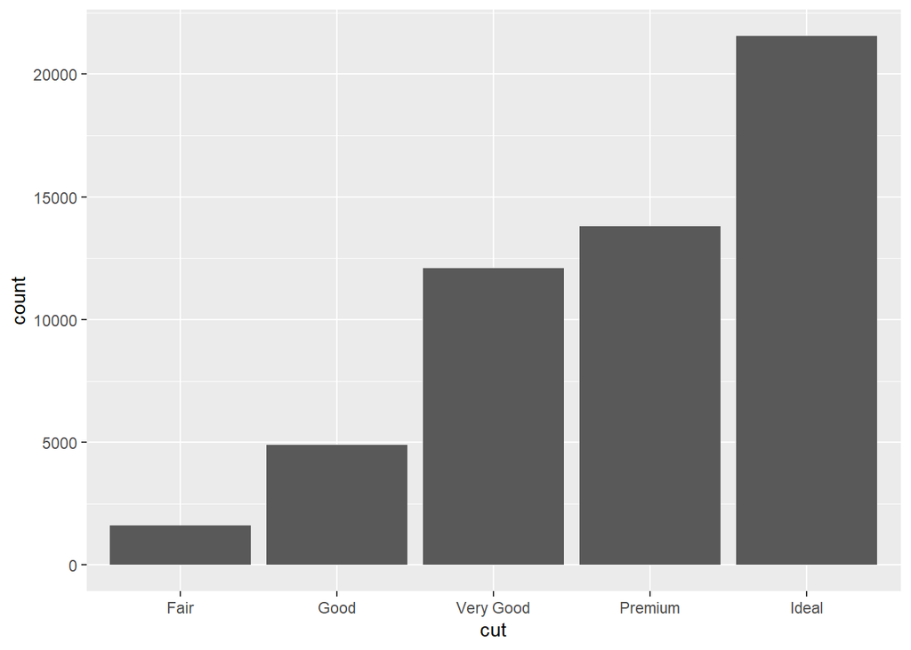

```r
ggplot(diamonds)+
  geom_bar(aes(cut))
```

Continuous variable,can take any of an infinite set of ordered values. Numbers and date-times are examples of continuous variables.

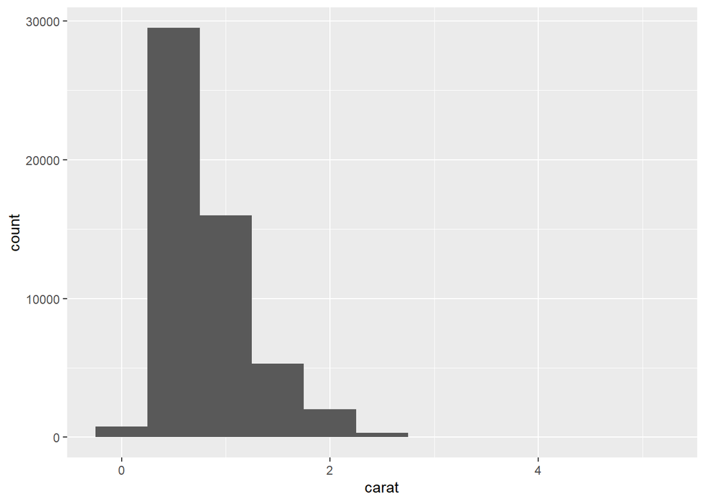

```r
ggplot(diamonds) +
  geom_histogram(aes(carat), binwidth = 0.5)
```

**Typical Values** are the common values of a variable. - Tall bars show common values - shorter bars show less-common values

1. Which values are the most common?
2. Which values are rare? Is this match your expectations?
3. Any unusual patterns? If yes, what might explain them?
   - Source: Chapter 5: Exploratory Data Analysis pg 88

**Unusual Values** are observations that do not seem to fit the pattern, also called outliers. These can occur from data entry errors or may be from interesting points of study.

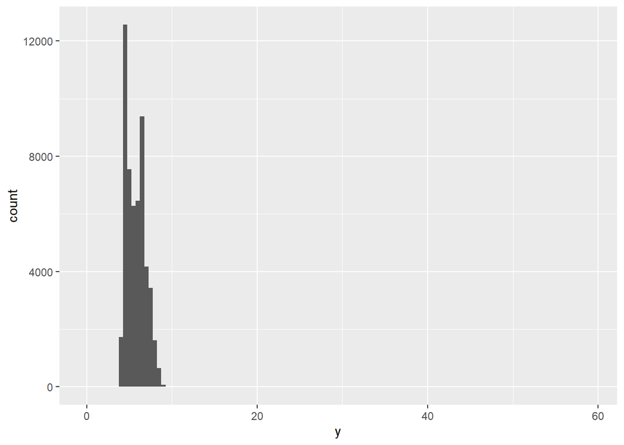

```r
ggplot(diamonds) +
  geom_histogram(aes(x=y), binwidth = 0.5)
```

It is hard to see the outlier here. The only hint is that the y axis is so wide. This indicates that somewhere around 60, there is an observation of that value, otherwise it would not have been included automatically in the graph. If we want to “zoom in” to see the unusual values, you can add another line of code:

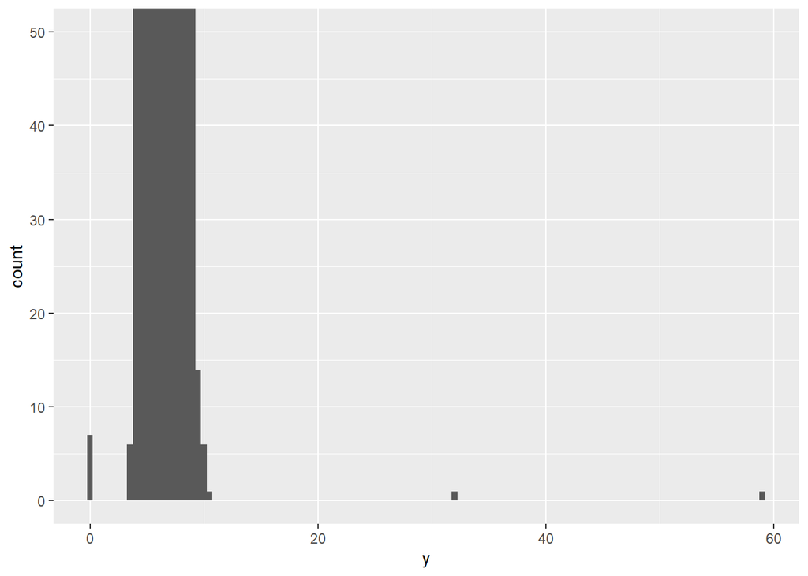

```r
ggplot(diamonds) +
  geom_histogram(aes(x=y), binwidth = 0.5) +
  coord_cartesian(ylim = c(0,50))
```

If you want want to zoom in on the x-axis, there is also an xlim() argument. If we want to visualize or analyze the data without the outliers, we can filter() them out using *dplyr*.

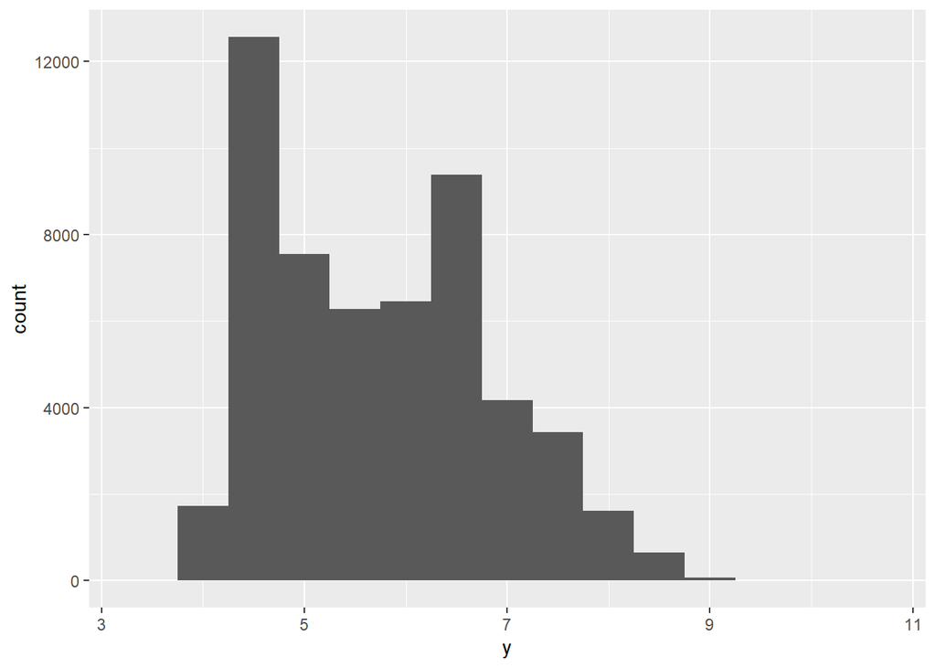

```r
obs <- diamonds %>%
  filter(y > 3 & y < 20)  %>%
  arrange(y)
ggplot(obs) +
  geom_histogram(aes(x=y), binwidth = 0.5)
```

If we want to examine the outliers closely, we can also use filter to achieve our goals. Outliers are not necessarily a mistake or a bad thing. Many case studies are intensive research on only outliers. (Much of the work I do involves looking at outliers)

```r
outliers <- diamonds %>%
  filter(y < 3 | y > 20)  %>%
  arrange(y)
outliers
```

```
## # A tibble: 9 x 10
##   carat cut       color clarity depth table price     x     y     z
##   <dbl> <ord>     <ord> <ord>   <dbl> <dbl> <int> <dbl> <dbl> <dbl>
## 1  1    Very Good H     VS2      63.3    53  5139  0      0    0
## 2  1.14 Fair      G     VS1      57.5    67  6381  0      0    0
## 3  1.56 Ideal     G     VS2      62.2    54 12800  0      0    0
## 4  1.2  Premium   D     VVS1     62.1    59 15686  0      0    0
## 5  2.25 Premium   H     SI2      62.8    59 18034  0      0    0
## 6  0.71 Good      F     SI2      64.1    60  2130  0      0    0
## 7  0.71 Good      F     SI2      64.1    60  2130  0      0    0
## 8  0.51 Ideal     E     VS1      61.8    55  2075  5.15  31.8  5.12
## 9  2    Premium   H     SI2      58.9    57 12210  8.09  58.9  8.06
```

**Missing Values**

```r
# is.na() #

# ifelse(diamonds %>% mutate( y = ifelse( y < 3 | y > 20, NA, y)))
# if y is less than 3 or greater than 2, change y to a missing value, otherwise leave it alone
```

**Covariation** is when variation describes the behavior *between* variables (Reminder: variation describes behavior *within* a singular variable). The easiest way to spot covariation is to visualize the relationship between the two variables. Depending on the types of variables determines the best ways to visualize the relationships.

Categorical & Continuous Variables A frequency graph does a good job breaking down a continuous variable by a categorical variable. Histograms and vertical or horizontal bar graphs

**Boxplots** are a type of visual shorthand for distribution. The box stretches from the 25th percentile to the 75th percetile of the distribution (so the middle 50% of all observations, also known as the interquartile range). In the middle of the box is a line that shows the **median** value in the observations. Together, these help show the spread of the distribution, if it is symmetric around the median, and if it is skewed in one direction or the other.

Outliers that are 1.5 times the IQR are plotted individually.

A line (or a *whisker*) extends from the ends of the box to the farthest nonoutlier point in the distribution.

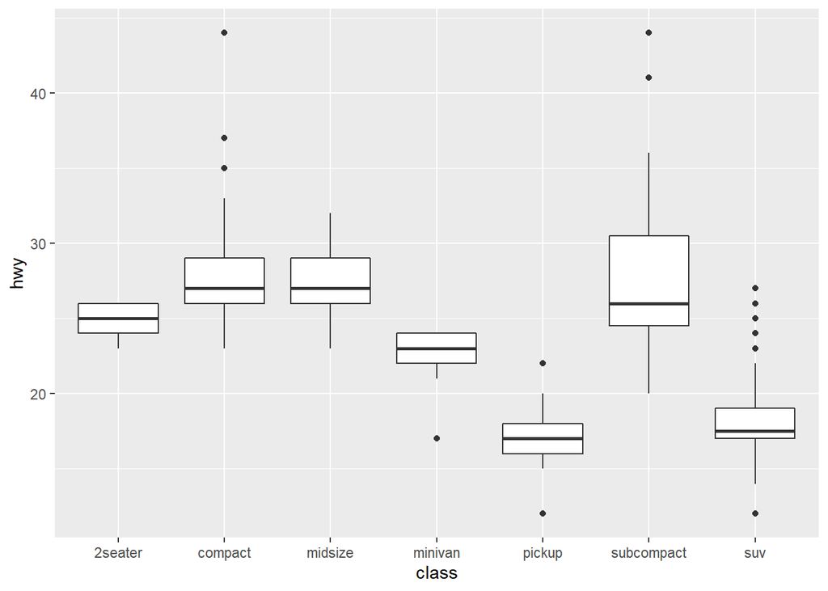

```r
ggplot(data = mpg) +
  geom_boxplot(
  mapping = aes(class, y = hwy)
)
```

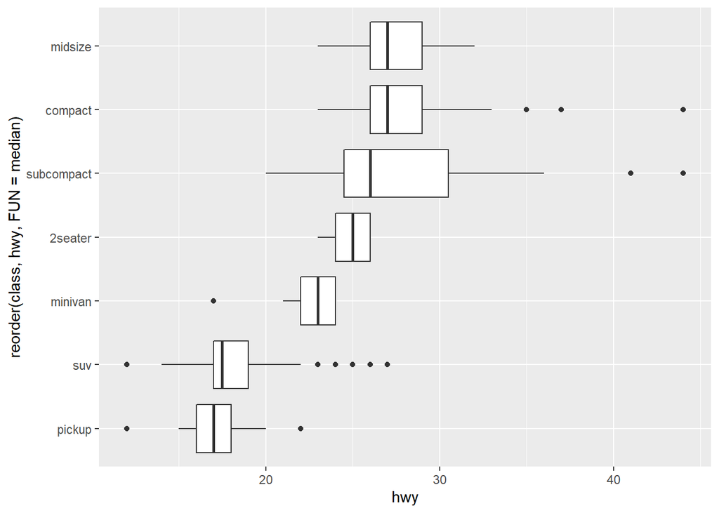

```r
ggplot(data = mpg) +
  geom_boxplot(
  mapping = aes(x = reorder( class, hwy, FUN = median), y = hwy)
) + coord_flip()
```

*Two Categorical Variables* Covariation between categorical variables is os visualized by examing the number of observations for each combination.

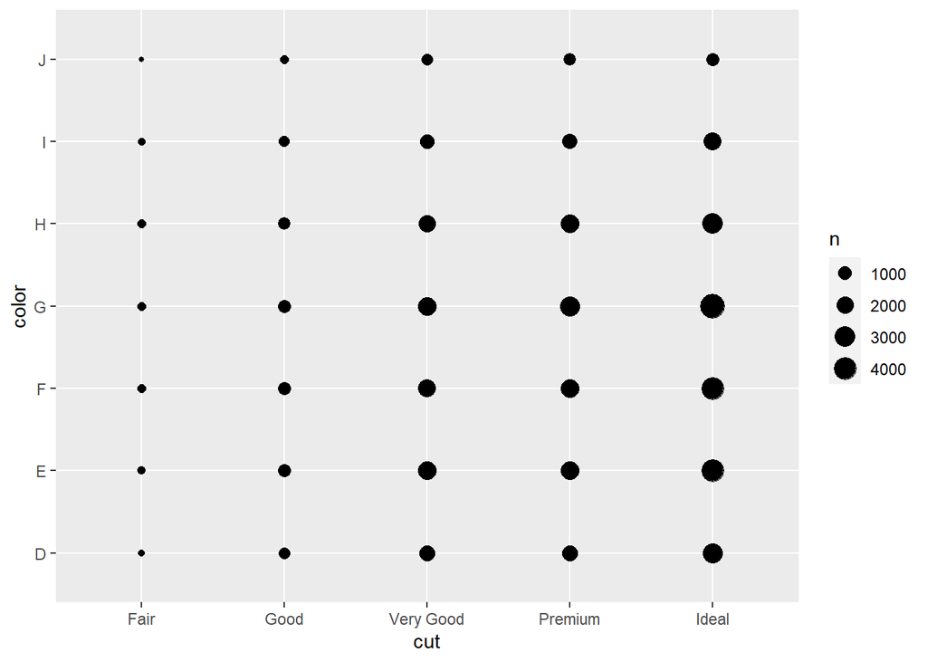

```r
ggplot(diamonds) +
  geom_count(mapping = aes(x=cut, y = color))
```

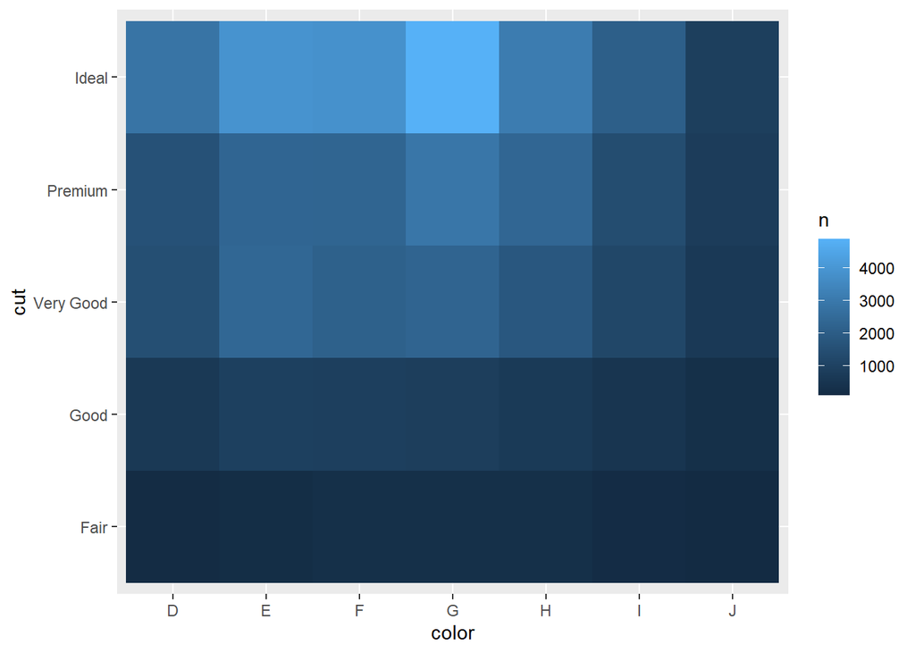

```r
diamonds %>% count(color, cut) %>%
  ggplot(aes(color, cut)) +
  geom_tile(aes(fill = n))
```

*Two Continuous Variables* Scatterplot with geom_point()

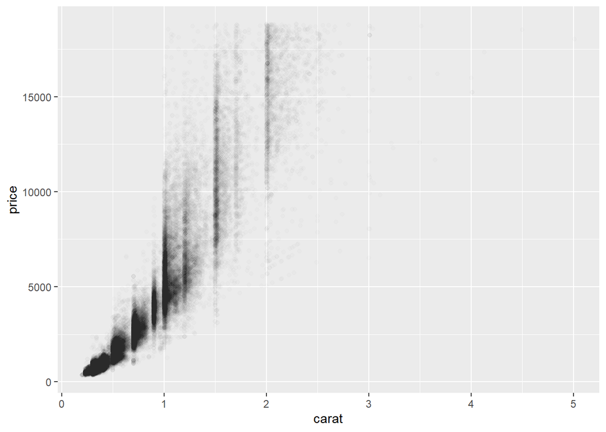

```r
ggplot(diamonds) +
  geom_point(aes(carat, price),
             alpha = .01) # adds transparency
```

# Codeing Etiquette

## Comments

You can leave comments in between pieces of code. This will be particularly help when we get to graphs.

```r
# Create a pie chart graph representing the activities done in reality.

reality <-
  # Call the dataset that I want to use "lockdown_reality"
  ggplot(lockdown_reality,
  # This section seems to create the basic pie chart graph by setting key parameters
  # fill represents the size of the pie slices
  aes( x = "", y = reality_timespent, fill = reality_activities)) +
  geom_bar( stat = "identity", color = "red", size = 2) +
  coord_polar( "y", start = 0 ) +
  theme_void() +
  theme(
        # Create a legent and put it at the bottom
        legend.position = "bottom",
        # Eliminate title?
        legend.title = element_blank(),
        legend.direction = "horizontal",
        plot.title = element_text(hjust = 0.5, size=22, face="bold", color="red"))+
  scale_fill_brewer(palette="Dark2") +
  ggtitle("Reality")
```

*Why so much emphasis on code??*

1. You need to make your code reproducible by others. This means explaining to them (and your future self) what you did at each stage and how the code words.
- Trust me, you are going to forget
- Your colleagues will very much appreciate this!
2. This is a way of leanring by noting down stuff that you notice and think about them. It will also help identifying parts that you don’t understand about your code and ask questions!

### Nice and ugly codes

Writing “nice” codes is about:

- Always leave a space before and after a symbol

**Ugly codes**

```r
2*3

object1<-2
```

**Nice codes**

```r
2 * 3

object1 <- 2
```

- This rule applies to commas as well
- BUT we don’t leave spaces before and after parantheses

**Ugly codes**

```r
object1<-c(9,3,4,1)

object1 <- c ( 9,3,4,1 )
```

**Nice codes**

```r
object1 <- c(9,3,4,1)

#Even more correct:
object1 <- c(9, 3, 4, 1)
```

Keep noticing this as we move forward and get yourself used to write nice codes since the very beginning: habits are difficult to change!

Note: When you recode a variable, it’s good practice to save it as a new one.

- It allows you to check your work
- You might need to go back to the original variable
- If you make a mistake, you don’t have to upload your dataset again
- You can always clean your dataframe at the end (e.g., keep only relevant columns)

### Quick exercise

```r
lockdown_exp<-as.data.frame(cbind(exp_activities,exp_timespent))
lockdown_exp

lockdown_reality<-as.data.frame(cbind(reality_activities,reality_timespent))
lockdown_reality

library("ggplot2")
full_plot<-plot_grid(Planned,Happened,
                     align="h",
                     labels="Planned VS Happened During the Lockdown",
                     label_size=27,
                     label_fontface="plain",
                     label_colour="black",
                     label_x=-0.47,label_y=0.95)
```

### Example

**1) Create a vector storing the following values: 3,2,1,4,1 representing the number of hours Mary watched TV this week. Name it appropriately**

**2) Calculate the average number of hours that Mary watched TV**

### ggplot2 Calls

Line of code where each argument is specified:

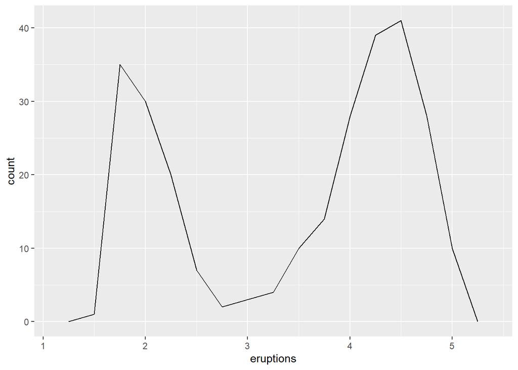

```r
ggplot(data = faithful, mapping = aes(x = eruptions)) +
  geom_freqpoly(binwidth = 0.25)
```

Line of code without each argument specified:

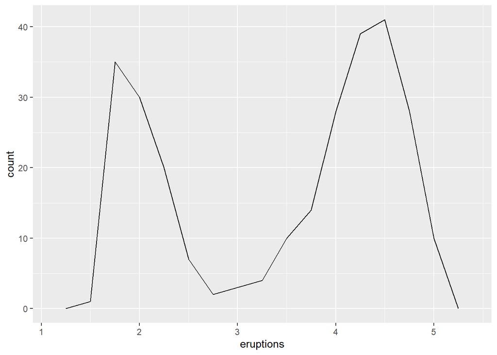

```r
ggplot(faithful, aes(eruptions)) +
  geom_freqpoly(binwidth = 0.25)
```

Including the arguments can be very helpful for your future self or if you are sharing your code with other people. Inclusion of the argument and clean, readable code can help you find mistakes faster and collaborate easier.

```r
# Create vector storing the number of TV hours watched
tv_hours <- c(3, 2, 1, 4, 1)

# Calculate the average number of TV hours watched
mean(tv_hours)

# 1. The average number of hours is 2.2
```

R is an open source software whose packages are developed by several individuals around the world. This means that there are several ways to “code” in R and get to the same output.

# Tips for myself later

If needed, you can also set text into your inline codes simply using the format **`` `mean(XXX)` ``**.

This will report your results into the text and save you time when updating your work!

Markdown Tips: Note that the `echo = FALSE` parameter was added to the code chunk to prevent printing of the R code that generated the plot.

You can make little tables with words.

example:

| Function | When to use it |
| --- | --- |
| **fct_relevel():** | Reorder factor levels by hand |
| **fct_inorder():** | Reorder factor levels by first appearance |
| **fct_infreq():** | Reorder factor levels by frequency |
| **fct_inseq():** | Reorder factor levels by numeric order |
| **fct_rev():** | Reverse order of factor levels |
| **fct_reorder():** | Reorder factor levels by sorting along another variable (great fro cat-cont graphs) |
| **fct_reorder2():** | Reorder factor levels by sorting along 2 other variables |